# Compare MPT Analysis Approaches

Marius Barth

2018-11-09

# Prerequisites

First of all, make sure that you have installed the *latest* version of all necessary `R` packages *and* of `JAGS`. To install `JAGS`, go to [mcmc-jags.sourceforge.net](http://mcmc-jags.sourceforge.net/) and follow installation instructions. After that, install or update the required R packages:

```r
install.packages("MPTmultiverse")
update.packages(ask = FALSE)
```

## Example 1: Bayen & Kuhlmann (2011)

```r
# load packages
library("MPTmultiverse")

# If you're running the analysis from an .rmd file, you only need to ensure that
# the .rmd, .eqn, and .csv files are all in the same directory.

# ------------------------------------------------------------------------------
# MPT model definition & data

EQN_FILE <- "2HTSM_Submodel4.eqn"
DATA_FILE <- "Kuhlmann_dl7.csv"


# if .csv format uses semicolons ";" (German format):
data <- read.csv2(DATA_FILE, fileEncoding = "UTF-8-BOM")

# if .csv format uses commata "," (international format):
# data <- read.csv(DATA_FILE, fileEncoding = "UTF-8-BOM")

# take a glimpse at the data
head(data)
```

```
#>   Subject ExpCond Yee Yeu Yen Yue Yuu Yun Yne Ynu Ynn
#> 1     110       1   6  12   5   2  18   5   0   2  14
#> 2     138       1  11   8   6   3  16   4   2   2  12
#> 3     141       1   9  10   7   1  16   5   2   1  13
#> 4     149       1  10   9   4   0  19   6   0   0  16
#> 5     102       1  12   4   8   5  11   8   0   0  16
#> 6     105       1  14   2   5   1  19   7   2   0  14
```

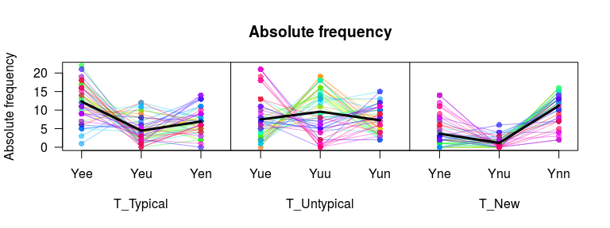

```r
TreeBUGS::plotFreq(data, boxplot = FALSE, eqn = EQN_FILE)
```

```r
COL_ID <- "Subject"         # name of the variable encoding subject ID
COL_CONDITION <- "ExpCond"  # name of the variable encoding group membership


# Experimental conditions should be labeled in a meaningful way. To accomplish
# this, you may want to use the `factor` function:
unique(data[, COL_CONDITION])
```

```
#> [1] 1 2
```

```r
data[[COL_CONDITION]] <- factor(
  data[[COL_CONDITION]]
  , levels = c(1:2)
  , labels = c("no_load", "load")
)

### check input data frame
head(data)
```

```
#>   Subject ExpCond Yee Yeu Yen Yue Yuu Yun Yne Ynu Ynn
#> 1     110 no_load   6  12   5   2  18   5   0   2  14
#> 2     138 no_load  11   8   6   3  16   4   2   2  12
#> 3     141 no_load   9  10   7   1  16   5   2   1  13
#> 4     149 no_load  10   9   4   0  19   6   0   0  16
#> 5     102 no_load  12   4   8   5  11   8   0   0  16
#> 6     105 no_load  14   2   5   1  19   7   2   0  14
```

### Options

Every time the package `MPTmultiverse` is loaded, it automatically sets some more or less useful defaults for model estimation, usage of multiple processor cores, number of posterior predictive samples, etc. By calling `mpt_options()` without any parameters, you can inspect these default values. If you want to change them, call `mpt_options` with the respective parameter specified, i.e. `mpt_options(n.iter = 1000)`. For testing purposes, you can also specify `mpt_options("test")`, which is a shorthand for setting fast, but highly unreliable settings. You can set options to defaults, again, by typing the shorthand `mpt_options("default")`.

```r
# How to change a single option:
mpt_options(n.iter = 1e3)

# For testing purposes, you can use this shorthand to set fast, but unreliable options:
mpt_options("test")

# List all options that were set for the different analysis approaches:
mpt_options()
```

### Estimation

In the next chunk, the main computations are done. Type `?fit_mpt` in the R console if you want to find out more about the parameters of the function.

```r
results <- fit_mpt(
  model = EQN_FILE
  , dataset = DATA_FILE
  , data = data
  , id = COL_ID
  , condition = COL_CONDITION
  , core = c("D", "d")
)
```

After computations finished, which may take a couple of days, check if model estimation worked by using the function `check_results`.

```r
check_results(results)
```

```
#> ## MPTinR: no pooling
#> Convergence checks failed for unkown reason.
#>
#>
#> ## MPTinR: complete pooling
#> No convergence problems.
#>
#>
#> ## TreeBUGS, no, simple:
#> All Rhat < 1.05 .
#> All effect sample sizes > 2000 .
#>
#>
#> ## TreeBUGS, complete, simple:
#> All Rhat < 1.05 .
#> All effect sample sizes > 2000 .
#>
#>
#> ## TreeBUGS, partial, trait:
#> All Rhat < 1.05 .
#> All effect sample sizes > 2000 .
#>
#>
#> ## TreeBUGS, partial, trait_uncorrelated:
#> All Rhat < 1.05 .
#> All effect sample sizes > 2000 .
#>
#>
#> ## TreeBUGS, partial, beta:
#> All Rhat < 1.05 .
#> All effect sample sizes > 2000 .
#>
#>
#> ## TreeBUGS, partial, betacpp:
#> All Rhat < 1.05 .
#> 28 parameters with effect sample size n.eff < 2000 :
#> sd[2], sd[3], alph[2], alph[3], bet[2], bet[3], mean[2], sd[2], sd[3], alph[2], alph[3], bet[2], bet[3], theta[2,4], theta[2,5], theta[2,6], theta[2,8], theta[2,9], theta[2,10], theta[2,11], theta[2,13], theta[2,14], theta[2,15], theta[2,17], theta[2,18], theta[2,19], theta[2,21], theta[2,22]
```

```r
# store results
save(
  results
  , file = "results_bayen_kuhlmann.RData"
)
```

### Post-processing of Results

The analysis output `results` is an object of class `multiverseMPT`, that has its own `plot()` method. Type `?plot.multiverseMPT` to see the documentation of possible arguments to this method.

To plot group-level parameter estimates, type:

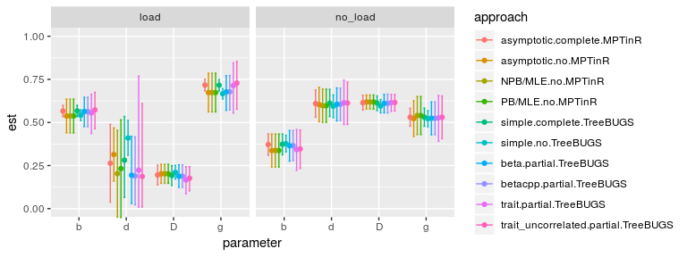

```r
plot(results, save = FALSE, "est")
```

To plot between-subjects comparisons, type:

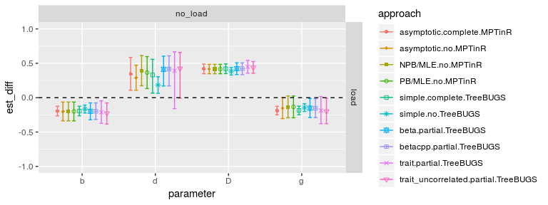

```r
plot(results, save = FALSE, "test_between")
```

To plot overall goodness-of-fit, type:

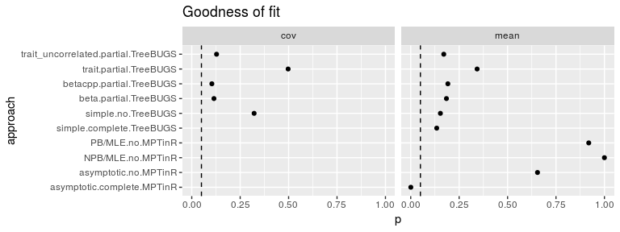

```r
plot(results, save = FALSE, "gof1")
```

To plot group-wise goodness-of-fit, type:

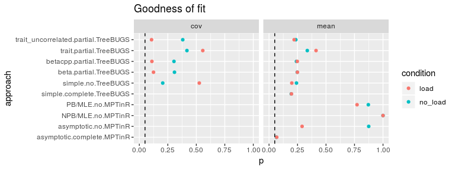

```r
plot(results, save = FALSE, "gof2")
```